# editedbyabinash

```python
import pandas as pd
import numpy as np
import matplotlib.pyplot as plt
import seaborn as sns
```

## Import Data

```python
df = pd.read_csv('./data/Dry_Bean_Dataset.csv')
```

## Data Description

```python
df.sample(5)
```

|  | Area | Perimeter | MajorAxisLength | MinorAxisLength | AspectRation | Eccentricity | ConvexArea | EquivDiameter | Extent | Solidity | roundness | Compactness | ShapeFactor1 | ShapeFactor2 | ShapeFactor3 | ShapeFactor4 | Class |
| --- | --- | --- | --- | --- | --- | --- | --- | --- | --- | --- | --- | --- | --- | --- | --- | --- | --- |
| 1252 | 40695 | 730.309 | 256.912105 | 201.886147 | 1.272559 | 0.618458 | 41014 | 227.627949 | 0.759518 | 0.992222 | 0.958821 | 0.886015 | 0.006313 | 0.002400 | 0.785022 | 0.998988 | SEKER |
| 2385 | 63732 | 1018.891 | 341.236173 | 238.580159 | 1.430279 | 0.714961 | 65059 | 284.861550 | 0.767107 | 0.979603 | 0.771457 | 0.834793 | 0.005354 | 0.001604 | 0.696879 | 0.996732 | BARBUNYA |
| 11827 | 31868 | 658.384 | 242.074174 | 167.974542 | 1.441136 | 0.720074 | 32219 | 201.433855 | 0.709202 | 0.989106 | 0.923860 | 0.832116 | 0.007596 | 0.002247 | 0.692417 | 0.997868 | DERMASON |
| 5978 | 48859 | 863.902 | 352.650109 | 177.410363 | 1.987765 | 0.864241 | 49441 | 249.417744 | 0.802599 | 0.988228 | 0.822670 | 0.707267 | 0.007218 | 0.001114 | 0.500226 | 0.994333 | HOROZ |
| 10556 | 26811 | 599.474 | 219.356830 | 155.696621 | 1.408873 | 0.704416 | 27140 | 184.761537 | 0.736951 | 0.987878 | 0.937524 | 0.842288 | 0.008182 | 0.002540 | 0.709448 | 0.999523 | DERMASON |

```python
df.shape
```

```
(13611, 17)
```

```python
df["Class"].unique()
```

```
array(['SEKER', 'BARBUNYA', 'BOMBAY', 'CALI', 'HOROZ', 'SIRA', 'DERMASON'],
      dtype=object)
```

```python
df.describe()
```

|  | Area | Perimeter | MajorAxisLength | MinorAxisLength | AspectRation | Eccentricity | ConvexArea | EquivDiameter | Extent | Solidity | roundness | Compactness | ShapeFactor1 | ShapeFactor2 | ShapeFactor3 | ShapeFactor4 |
| --- | --- | --- | --- | --- | --- | --- | --- | --- | --- | --- | --- | --- | --- | --- | --- | --- |
| count | 13611.000000 | 13611.000000 | 13611.000000 | 13611.000000 | 13611.000000 | 13611.000000 | 13611.000000 | 13611.000000 | 13611.000000 | 13611.000000 | 13611.000000 | 13611.000000 | 13611.000000 | 13611.000000 | 13611.000000 | 13611.000000 |
| mean | 53048.284549 | 855.283459 | 320.141867 | 202.270714 | 1.583242 | 0.750895 | 53768.200206 | 253.064220 | 0.749733 | 0.987143 | 0.873282 | 0.799864 | 0.006564 | 0.001716 | 0.643590 | 0.995063 |
| std | 29324.095717 | 214.289696 | 85.694186 | 44.970091 | 0.246678 | 0.092002 | 29774.915817 | 59.177120 | 0.049086 | 0.004660 | 0.059520 | 0.061713 | 0.001128 | 0.000596 | 0.098996 | 0.004366 |
| min | 20420.000000 | 524.736000 | 183.601165 | 122.512653 | 1.024868 | 0.218951 | 20684.000000 | 161.243764 | 0.555315 | 0.919246 | 0.489618 | 0.640577 | 0.002778 | 0.000564 | 0.410339 | 0.947687 |
| 25% | 36328.000000 | 703.523500 | 253.303633 | 175.848170 | 1.432307 | 0.715928 | 36714.500000 | 215.068003 | 0.718634 | 0.985670 | 0.832096 | 0.762469 | 0.005900 | 0.001154 | 0.581359 | 0.993703 |
| 50% | 44652.000000 | 794.941000 | 296.883367 | 192.431733 | 1.551124 | 0.764441 | 45178.000000 | 238.438026 | 0.759859 | 0.988283 | 0.883157 | 0.801277 | 0.006645 | 0.001694 | 0.642044 | 0.996386 |
| 75% | 61332.000000 | 977.213000 | 376.495012 | 217.031741 | 1.707109 | 0.810466 | 62294.000000 | 279.446467 | 0.786851 | 0.990013 | 0.916869 | 0.834270 | 0.007271 | 0.002170 | 0.696006 | 0.997883 |
| max | 254616.000000 | 1985.370000 | 738.860154 | 460.198497 | 2.430306 | 0.911423 | 263261.000000 | 569.374358 | 0.866195 | 0.994677 | 0.990685 | 0.987303 | 0.010451 | 0.003665 | 0.974767 | 0.999733 |

## Data cleaning

```python
df.isnull().sum()
```

```
Area               0
Perimeter          0
MajorAxisLength    0
MinorAxisLength    0
AspectRation       0
Eccentricity       0
ConvexArea         0
EquivDiameter      0
Extent             0
Solidity           0
roundness          0
Compactness        0
ShapeFactor1       0
ShapeFactor2       0
ShapeFactor3       0
ShapeFactor4       0
Class              0
dtype: int64
```

No missing values

```python
df.info()
```

```
<class 'pandas.core.frame.DataFrame'>
RangeIndex: 13611 entries, 0 to 13610
Data columns (total 17 columns):
 #   Column           Non-Null Count  Dtype
---  ------           --------------  -----
 0   Area             13611 non-null  int64
 1   Perimeter        13611 non-null  float64
 2   MajorAxisLength  13611 non-null  float64
 3   MinorAxisLength  13611 non-null  float64
 4   AspectRation     13611 non-null  float64
 5   Eccentricity     13611 non-null  float64
 6   ConvexArea       13611 non-null  int64
 7   EquivDiameter    13611 non-null  float64
 8   Extent           13611 non-null  float64
 9   Solidity         13611 non-null  float64
 10  roundness        13611 non-null  float64
 11  Compactness      13611 non-null  float64
 12  ShapeFactor1     13611 non-null  float64
 13  ShapeFactor2     13611 non-null  float64
 14  ShapeFactor3     13611 non-null  float64
 15  ShapeFactor4     13611 non-null  float64
 16  Class            13611 non-null  object
dtypes: float64(14), int64(2), object(1)
memory usage: 1.8+ MB
```

```python
class_counts = df["Class"].value_counts()
print(class_counts)
```

```
Class
DERMASON    3546
SIRA        2636
SEKER       2027
HOROZ       1928
CALI        1630
BARBUNYA    1322
BOMBAY       522
Name: count, dtype: int64
```

# EDA

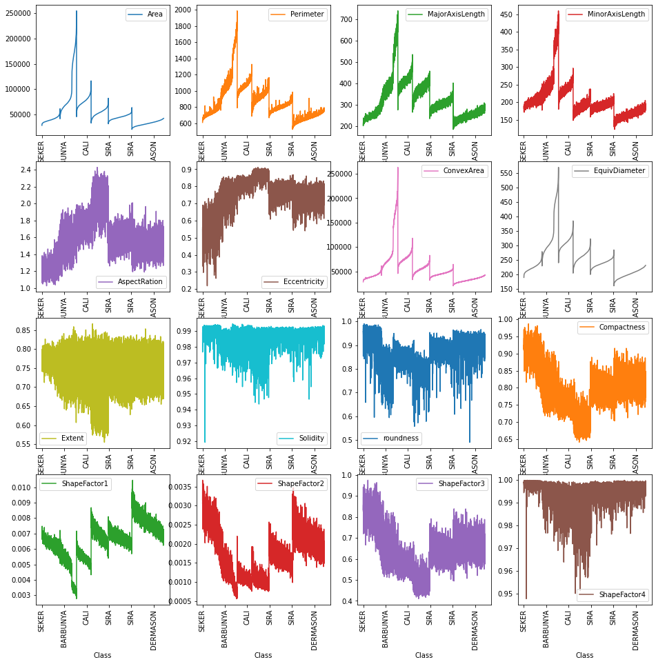

```python
indicators = df.columns[:-1]
df.plot(x = "Class", y = indicators, subplots = True, layout = (4, 4),
       figsize = (16, 16), sharex = False, rot = 90)
plt.show()
```

```python
unique_classes = df.Class.unique()
def draw_conditional_distribution(ax, df, col):
    bins = np.linspace(df[col].min(), df[col].max(), 50)
    for cls in unique_classes:
        ax.hist(df[df.Class == cls][col], alpha=0.5, label=cls, bins=bins)
    ax.set_title(f'Distributions for {col}')
    ax.legend()
```

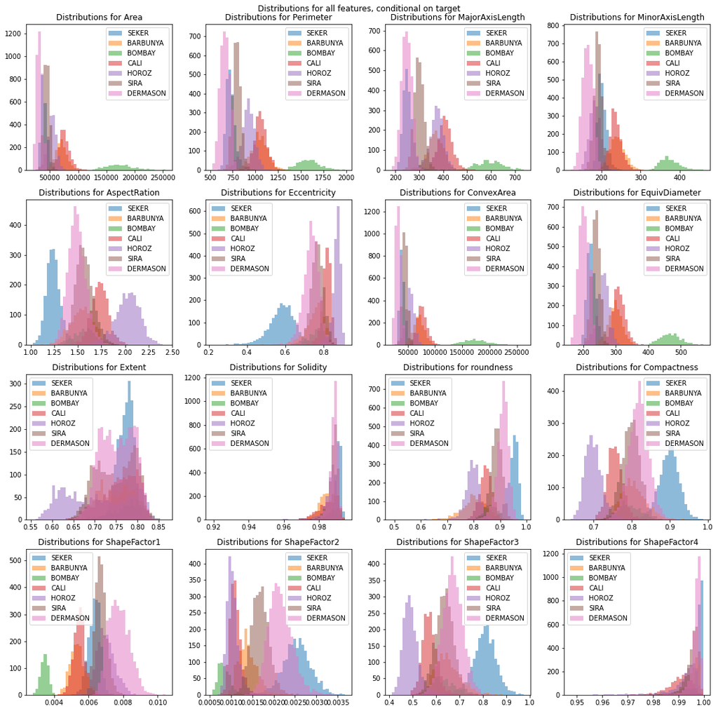

```python
fig, ax = plt.subplots(len(df.drop('Class', axis=1).columns) // 4, 4, figsize=(15, 15))
for idx, col in enumerate(df.drop('Class', axis=1).columns):
    draw_conditional_distribution(ax[idx // 4, idx % 4], df, col)
plt.suptitle('Distributions for all features, conditional on target')
plt.tight_layout()
plt.show()
```

Here you can immediately notice that the Bombay class is very different from the others. These grains are much larger than the others. There are very many features where we can separate objects of this class from objects of another with a probability very close to 1.

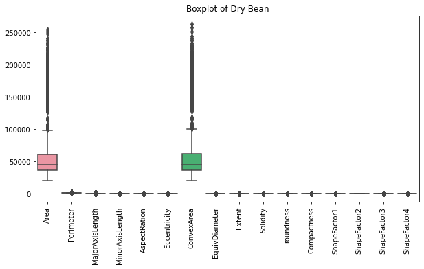

```python
# Check outlier of Dry Bean features
plt.figure(figsize = (10, 5))
sns.boxplot(df[indicators])
plt.title("Boxplot of Dry Bean")
plt.xticks(rotation = 90)
plt.show()
```

```python
removed = df[(df["Area"] >= 100000) & (df["ConvexArea"] >= 100000)]
```

```python
class_counts = removed["Class"].value_counts()
print(class_counts)
```

```
Class
BOMBAY      522
CALI         22
BARBUNYA      5
Name: count, dtype: int64
```

All the instaces from bombay category are outliers also, so we will not consider bobbay class any more

```python
# Delete outlier of "Area" & "ConvexArea"
df = df[(df["Area"] < 100000) | (df["ConvexArea"] < 100000)]
```

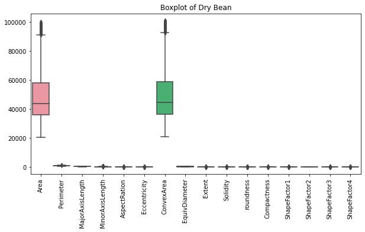

```python
# Check outlier of Dry Bean features
plt.figure(figsize = (10, 5))
sns.boxplot(df[indicators])
plt.title("Boxplot of Dry Bean")
plt.xticks(rotation = 90)
plt.show()
```

```python
print(df.shape)
print(df["Class"].unique())
```

```
(13062, 17)
['SEKER' 'BARBUNYA' 'CALI' 'HOROZ' 'SIRA' 'DERMASON']
```

```python
def draw_scatterplot(ax, col1, col2, df):
    unique_labels = df.Class.unique()
    for cls in unique_labels:
        filtered = df[df.Class == cls]
        ax.scatter(filtered[col1], filtered[col2], label=cls, alpha=0.2)
    ax.legend()
    ax.set_xlabel(col1)
    ax.set_ylabel(col2)
    ax.set_title(f'Joint scatterplot: {col1} & {col2}')
```

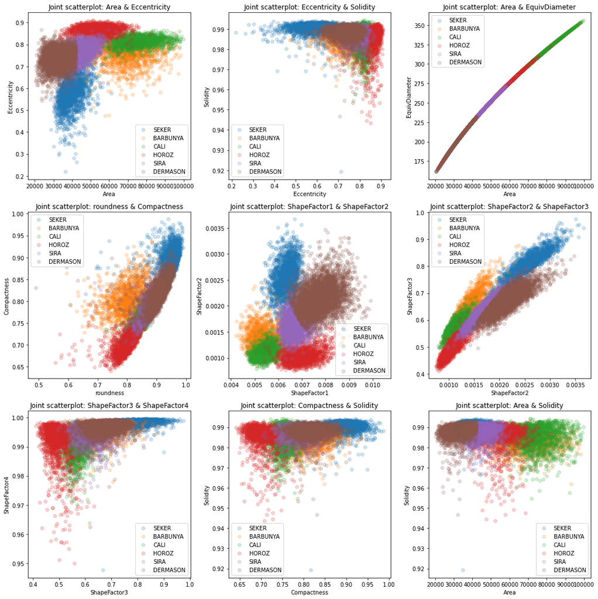

```python
fig, ax = plt.subplots(3, 3, figsize=(15, 15))
pairs = [('Area', 'Eccentricity'), ('Eccentricity', 'Solidity'), ('Area', 'EquivDiameter'), ('roundness', 'Compactness'),
         ('ShapeFactor1', 'ShapeFactor2'), ('ShapeFactor2', 'ShapeFactor3'), ('ShapeFactor3', 'ShapeFactor4'), ('Compactness', 'Solidity'),
         ('Area', 'Solidity')]
for idx, p in enumerate(pairs):
    draw_scatterplot(ax[idx // 3, idx % 3], *p, df)
plt.tight_layout()
plt.show()
```

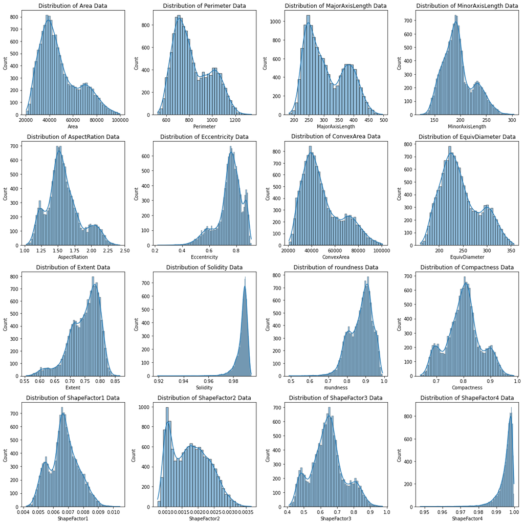

```python
import warnings
warnings.filterwarnings('ignore')
import seaborn as sns
plt.figure(figsize = (16, 16))
for i, col in enumerate(indicators, 1):
    plt.subplot(4, 4, i)
    sns.histplot(df[col], kde= True)
    plt.title(f"Distribution of {col} Data")
    plt.tight_layout()
    plt.plot()
```

Preprocessing

```python
# Correlation of Dry Bran with Class
from sklearn.preprocessing import LabelEncoder
le = LabelEncoder()
df["Class"] = le.fit_transform(df["Class"])
df_corr = df.corr()
df_corr["Class"].sort_values(ascending = False)
```

```
Class              1.000000
roundness          0.362622
Solidity           0.320695
ShapeFactor2       0.268620
ShapeFactor1       0.242638
ShapeFactor3       0.188754
Compactness        0.178909
ShapeFactor4       0.155742
Extent             0.000110
AspectRation      -0.144175
Eccentricity      -0.216365
MinorAxisLength   -0.350952
MajorAxisLength   -0.365682
EquivDiameter     -0.395852
Perimeter         -0.422265
Area              -0.440134
ConvexArea        -0.443145
Name: Class, dtype: float64
```

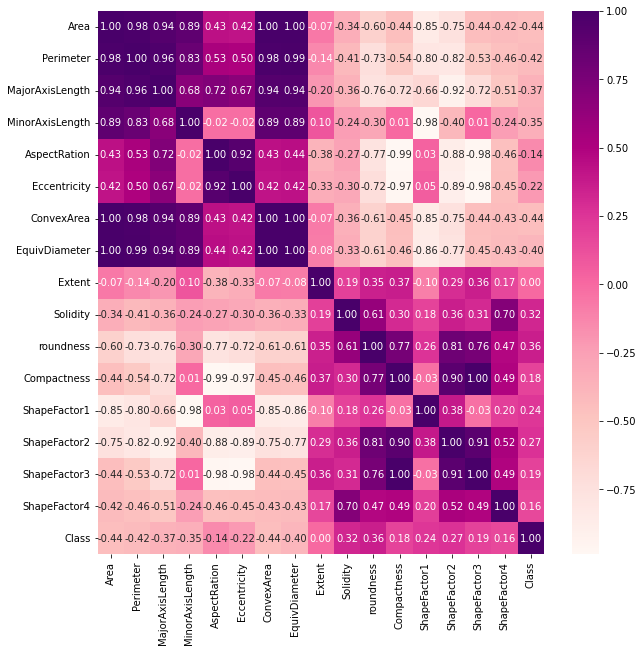

```python
plt.figure(figsize = (10, 10))
sns.heatmap(df_corr, cmap = 'RdPu', annot = True, fmt = ".2f")
plt.show()
```

```python
# Split Train/Test
X = df.iloc[:,:-1]
y = df.iloc[:, -1]
from sklearn.model_selection import train_test_split
X_train, X_test, y_train, y_test = train_test_split(X, y, test_size = 0.2, random_state = 0)
```

Logistic Regression Model

```python
# LogisticRegressor - Not Scaled
from sklearn.linear_model import LogisticRegression
lr = LogisticRegression()
lr.fit(X_train, y_train)
y_lr = lr.predict(X_test)

# Model Score
from sklearn.metrics import mean_absolute_error
print("Normal Score :", lr.score(X_test, y_test))
print("Mean Absolute Error :", mean_absolute_error(y_test, y_lr))
```

```
Normal Score : 0.7474167623421355
Mean Absolute Error : 0.4623038652889399
```

Decision Tree Model

```python
from sklearn.tree import DecisionTreeRegressor
from sklearn.metrics import mean_absolute_error

# Create Decision Tree Regressor
dtr = DecisionTreeRegressor()

# Train Decision Tree Regressor not scaled
dtr.fit(X_train, y_train)

# Predict using Decision Tree Regressor
y_dtr = dtr.predict(X_test)

# Model Score
print("Normal Score :", dtr.score(X_test, y_test))
print("Mean Absolute Error :", mean_absolute_error(y_test, y_dtr))
```

```
Normal Score : 0.718784550133435
Mean Absolute Error : 0.25832376578645233
```

SVM Model

```python
from sklearn.svm import SVC

# Create SVM Classifier
svm_classifier = SVC()

# Train SVM Classifier Not Scaled
svm_classifier.fit(X_train, y_train)

# Predict using SVM Classifier
y_svm = svm_classifier.predict(X_test)

# Model Score
print("SVM Classifier Score:", svm_classifier.score(X_test, y_test))

# Mean Absolute Error
print("Mean Absolute Error:", mean_absolute_error(y_test, y_svm))
```

```
SVM Classifier Score: 0.6276310753922695
Mean Absolute Error: 0.6521239954075775
```

Scaling the dataset

```python
# Feature Scaling
from sklearn.preprocessing import StandardScaler
sc = StandardScaler()
X_train_sc = sc.fit_transform(X_train)
X_test_sc = sc.transform(X_test)
```

Logistic Regression Scaled

```python
# LogisticRegressor - Scaled
from sklearn.linear_model import LogisticRegression
lr = LogisticRegression()
lr.fit(X_train_sc, y_train)
y_lr = lr.predict(X_test_sc)

# Model Score
from sklearn.metrics import mean_absolute_error
print("Normal Score :", lr.score(X_test_sc, y_test))
print("Mean Absolute Error :", mean_absolute_error(y_test, y_lr))
```

```
Normal Score : 0.9181017986988136
Mean Absolute Error : 0.20321469575200918
```

Decision Tree Regression Scaled

```python
from sklearn.tree import DecisionTreeRegressor
from sklearn.metrics import mean_absolute_error

# Create Decision Tree Regressor
dtr = DecisionTreeRegressor()

# Train Decision Tree Regressor Scaled
dtr.fit(X_train_sc, y_train)

# Predict using Decision Tree Regressor
y_dtr = dtr.predict(X_test_sc)

# Model Score
print("Normal Score :", dtr.score(X_test_sc, y_test))
print("Mean Absolute Error :", mean_absolute_error(y_test, y_dtr))
```

```
Normal Score : 0.722935331681281
Mean Absolute Error : 0.2537313432835821
```

SVM Model Scaled

```python
# Create SVM Classifier
svm_classifier2 = SVC()

# Train SVM Classifier scaled
svm_classifier2.fit(X_train_sc, y_train)

# Predict using SVM Classifier
y_svm = svm_classifier2.predict(X_test_sc)

# Model Score
print("SVM Classifier Score:", svm_classifier2.score(X_test_sc, y_test))

# Mean Absolute Error
print("Mean Absolute Error:", mean_absolute_error(y_test, y_svm))
```

```
SVM Classifier Score: 0.9238423268274014
Mean Absolute Error: 0.18828932261768083
```

Using Kmeans clustering to delete outliers

```python
from sklearn.cluster import KMeans
km = KMeans(n_clusters = 2)
km.fit(df[indicators])
labels = km.labels_
df_km = df[labels == 1]
df_km.reset_index(inplace = True)
```

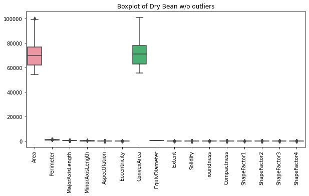

```python
plt.figure(figsize = (10, 5))
sns.boxplot(df_km[indicators])
plt.title("Boxplot of Dry Bean w/o outliers")
plt.xticks(rotation = 90)
plt.show()
```

```python
# Correlation of Dry Bran with Class
from sklearn.preprocessing import LabelEncoder
le = LabelEncoder()
df_km["Class"] = le.fit_transform(df_km["Class"])
```

```python
# Split Train/Test
X = df_km.iloc[:,:-1]
y = df_km.iloc[:, -1]
from sklearn.model_selection import train_test_split
X_train, X_test, y_train, y_test = train_test_split(X, y, test_size = 0.2, random_state = 0)

# Feature Scaling
from sklearn.preprocessing import StandardScaler
sc = StandardScaler()
X_train_sc = sc.fit_transform(X_train)
X_test_sc = sc.transform(X_test)
```

Logistic Regression with KMeans

```python
from sklearn.metrics import accuracy_score, precision_score, recall_score, f1_score, confusion_matrix



# LogisticRegressor - Scaled
from sklearn.linear_model import LogisticRegression
lr = LogisticRegression()
lr.fit(X_train_sc, y_train)
y_lr = lr.predict(X_test_sc)

# Model Score
from sklearn.metrics import mean_absolute_error
print("Normal Score :", lr.score(X_test_sc, y_test))
print("Mean Absolute Error :", mean_absolute_error(y_test, y_lr))

# Precision
precision = precision_score(y_test, y_lr, average='macro')
print("Precision:", precision)

# Recall
recall = recall_score(y_test, y_lr, average='macro')
print("Recall:", recall)

# F1 Score
f1 = f1_score(y_test, y_lr, average='macro')
print("F1 Score:", f1)

# Confusion Matrix
conf_matrix = confusion_matrix(y_test, y_lr)
print("Confusion Matrix:\n", conf_matrix)
```

```
Normal Score : 0.9959623149394348
Mean Absolute Error : 0.010767160161507403
Precision: 0.9317948717948716
Recall: 0.8993127147766323
F1 Score: 0.9131692794343398
Confusion Matrix:
 [[258   0   0   0   0]
 [  0 290   0   1   0]
 [  0   0 178   0   0]
 [  2   0   0   2   0]
 [  0   0   0   0  12]]
```

Decison Tree with Kmeans

```python
from sklearn.tree import DecisionTreeRegressor
from sklearn.metrics import mean_absolute_error
from sklearn.metrics import mean_absolute_error, mean_squared_error, r2_score


# Create Decision Tree Regressor
dtr = DecisionTreeRegressor()

# Train Decision Tree Regressor
dtr.fit(X_train_sc, y_train)

# Predict using Decision Tree Regressor
y_dtr = dtr.predict(X_test_sc)

# Model Score
print("Normal Score :", dtr.score(X_test_sc, y_test))
print("Mean Absolute Error :", mean_absolute_error(y_test, y_dtr))

# Mean Squared Error
mse = mean_squared_error(y_test, y_dtr)
print("Mean Squared Error:", mse)

# R-squared
r2 = r2_score(y_test, y_dtr)
print("R-squared:", r2)
```

```
Normal Score : 1.0
Mean Absolute Error : 0.0
Mean Squared Error: 0.0
R-squared: 1.0
```

SVM Model with Kmeans

```python
# Create SVM Classifier
svm_classifier2 = SVC()

# Train SVM Classifier scaled
svm_classifier2.fit(X_train_sc, y_train)

# Predict using SVM Classifier
y_svm = svm_classifier2.predict(X_test_sc)

# Model Score
print("SVM Classifier Score:", svm_classifier2.score(X_test_sc, y_test))

# Mean Absolute Error
print("Mean Absolute Error:", mean_absolute_error(y_test, y_svm))

# Precision
precision = precision_score(y_test, y_svm, average='macro')
print("Precision:", precision)

# Recall
recall = recall_score(y_test, y_svm, average='macro')
print("Recall:", recall)

# F1 Score
f1 = f1_score(y_test, y_svm, average='macro')
print("F1 Score:", f1)

# Confusion Matrix
conf_matrix = confusion_matrix(y_test, y_svm)
print("Confusion Matrix:\n", conf_matrix)
```

[output not shown]

Training and Testing using custom made Models

Custom Logistic Regression Model

```python
import numpy as np
import pandas as pd
import time
from sklearn.metrics import precision_score, recall_score, f1_score, confusion_matrix


class LogisticRegressionModel:
    def __init__(self, learning_rate=0.1, num_iter=1000):
        self.learning_rate = learning_rate
        self.num_iter = num_iter
        self.theta = None

    def sigmoid(self, X):
        z = np.dot(X, self.theta)
        return 1 / (1 + np.exp(-z))

    def gradient_descent(self, X, h, y):
        return np.dot(X.T, (h - y)) / y.shape[0]

    def update_weight(self, gradient):
        self.theta -= self.learning_rate * gradient

    def train(self, X, y):
        intercept = np.ones((X.shape[0], 1))
        X = np.concatenate((intercept, X), axis=1)
        self.theta = np.zeros(X.shape[1])

        for i in range(self.num_iter):
            h = self.sigmoid(X)
            gradient = self.gradient_descent(X, h, y)
            self.update_weight(gradient)


    def predict(self, X):
        intercept = np.ones((X.shape[0], 1))
        X = np.concatenate((intercept, X), axis=1)
        result = self.sigmoid(X)
        return np.where(result >= 0.5, 1, 0)

# Train and test functions
def train_and_test(X_train, y_train, X_test, y_test, learning_rate=0.1, num_iter=1000):
    model = LogisticRegressionModel(learning_rate=learning_rate, num_iter=num_iter)
    model.train(X_train, y_train)
    y_pred = model.predict(X_test)
    accuracy = np.mean(y_pred == y_test)
    print("Accuracy :", accuracy)

    # Precision
    precision = precision_score(y_test, y_pred, average='macro')
    print("Precision:", precision)

    # Recall
    recall = recall_score(y_test, y_pred, average='macro')
    print("Recall:", recall)

    # F1 Score
    f1 = f1_score(y_test, y_pred, average='macro')
    print("F1 Score:", f1)

    # Confusion Matrix
    conf_matrix = confusion_matrix(y_test, y_pred)
    print("Confusion Matrix:\n", conf_matrix)
```

```python
# Train and test the model
train_and_test(X_train_sc, y_train, X_test_sc, y_test)
```

```
Accuracy : 0.5733512786002691
Precision: 0.23029868058576194
Recall: 0.3144969231998721
F1 Score: 0.2658046370091987
Confusion Matrix:
 [[247  11   0   0   0]
 [112 179   0   0   0]
 [  0 178   0   0   0]
 [  4   0   0   0   0]
 [  0  12   0   0   0]]
```

Custom SVM Model

```python
import numpy as np
from sklearn.metrics import accuracy_score, precision_score, recall_score, f1_score, confusion_matrix


class Custom_SVM:

    def __init__(self, learning_rate=0.001, lambda_param=0.01, n_iters=1000):
        self.lr = learning_rate
        self.lambda_param = lambda_param
        self.n_iters = n_iters
        self.w = None
        self.b = None

    def fit(self, X, y):
        n_samples, n_features = X.shape

        y_ = np.where(y <= 0, -1, 1)

        self.w = np.zeros(n_features)
        self.b = 0

        for _ in range(self.n_iters):
            for idx, x_i in enumerate(X):
                condition = y_[idx] * (np.dot(x_i, self.w) - self.b) >= 1
                if condition:
                    self.w -= self.lr * (2 * self.lambda_param * self.w)
                else:
                    self.w -= self.lr * \
                        (2 * self.lambda_param * self.w - np.dot(x_i, y_[idx]))
                    self.b -= self.lr * y_[idx]

    def predict(self, X):
        approx = np.dot(X, self.w) - self.b
        return np.sign(approx)
```

```python
# Train the Custom_SVM model
svm_model = Custom_SVM()
svm_model.fit(X_train_sc, y_train)

# Predict on the testing data
y_pred = svm_model.predict(X_test_sc)
```

```python
# Calculate accuracy
from sklearn.metrics import confusion_matrix
def calculate_accuracy(y_true, y_pred):
    correct = 0
    total = len(y_true)
    for true, pred in zip(y_true, y_pred):
        if true == pred:
            correct += 1
    return correct / total

# Calculate precision


def calculate_precision(y_true, y_pred, positive_label=1):
    true_positive = 0
    predicted_positive = 0
    for true, pred in zip(y_true, y_pred):
        if pred == positive_label:
            predicted_positive += 1
            if true == pred:
                true_positive += 1
    if predicted_positive == 0:
        return 0
    return true_positive / predicted_positive

# Calculate recall


def calculate_recall(y_true, y_pred, positive_label=1):
    true_positive = 0
    actual_positive = 0
    for true, pred in zip(y_true, y_pred):
        if true == positive_label:
            actual_positive += 1
            if true == pred:
                true_positive += 1
    if actual_positive == 0:
        return 0
    return true_positive / actual_positive

# Calculate F1 score


def calculate_f1_score(precision, recall):
    if precision + recall == 0:
        return 0
    return 2 * (precision * recall) / (precision + recall)



# Assuming y_true and y_pred are the true labels and predicted labels, respectively
accuracy = calculate_accuracy(y_test, y_pred)
precision = calculate_precision(y_test, y_pred)
recall = calculate_recall(y_test, y_pred)
# Assuming precision and recall are calculated already
f1_score = calculate_f1_score(precision, recall)

print("Accuracy:", accuracy)
print("Precision:", precision)
print("Recall:", recall)
print("F1 Score:", f1_score)
conf_matrix = confusion_matrix(y_test, y_pred)
print("Confusion Matrix:\n", conf_matrix)
```

```
Accuracy: 0.3916554508748318
Precision: 0.604989604989605
Recall: 1.0
F1 Score: 0.7538860103626943
Confusion Matrix:
 [[  0   0   0   0   0   0]
 [258   0   0   0   0   0]
 [  0   0 291   0   0   0]
 [  0   0 178   0   0   0]
 [  4   0   0   0   0   0]
 [  0   0  12   0   0   0]]
```

Custom Decision Tree Model

```python
# imports
from __future__ import annotations
from typing import Tuple
from abc import ABC, abstractmethod
from scipy import stats
import numpy as np
import pandas as pd
import matplotlib.pyplot as plt
from sklearn.model_selection import train_test_split
from sklearn.datasets import load_breast_cancer, make_regression
from sklearn.metrics import accuracy_score, precision_score, recall_score, mean_squared_error, mean_absolute_error, r2_score


class Node(object):
    def __init__(self) -> None:
        self.__split = None
        self.__feature = None
        self.__left = None
        self.__right = None
        self.leaf_value = None

    def set_params(self, split: float, feature: int) -> None:
        self.__split = split
        self.__feature = feature

    def get_params(self) -> Tuple[float, int]:
        return (self.__split, self.__feature)

    def set_children(self, left: Node, right: Node) -> None:
        self.__left = left
        self.__right = right

    def get_left_node(self) -> Node:
        return (self.__left)

    def get_right_node(self) -> Node:
        return (self.__right)


class DecisionTree(ABC):
    def __init__(self, max_depth: int = None, min_samples_split: int = 2) -> None:
        self.tree = None
        self.max_depth = max_depth
        self.min_samples_split = min_samples_split

    @abstractmethod
    def _impurity(self, D: np.array) -> None:
        pass

    @abstractmethod
    def _leaf_value(self, D: np.array) -> None:
        pass

    def __grow(self, node: Node, D: np.array, level: int) -> None:
        depth = (self.max_depth is None) or (self.max_depth >= (level+1))
        msamp = (self.min_samples_split <= D.shape[0])
        n_cls = np.unique(D[:, -1]).shape[0] != 1

        if depth and msamp and n_cls:
            ip_node = None
            feature = None
            split = None
            left_D = None
            right_D = None
            for f in range(D.shape[1]-1):
                for s in np.unique(D[:, f]):
                    D_l = D[D[:, f] <= s]
                    D_r = D[D[:, f] > s]
                    if D_l.size and D_r.size:
                        ip = (D_l.shape[0]/D.shape[0])*self._impurity(D_l) + \
                            (D_r.shape[0]/D.shape[0])*self._impurity(D_r)
                        if (ip_node is None) or (ip < ip_node):
                            ip_node = ip
                            feature = f
                            split = s
                            left_D = D_l
                            right_D = D_r
            node.set_params(split, feature)
            left_node = Node()
            right_node = Node()
            node.set_children(left_node, right_node)
            self.__grow(node.get_left_node(), left_D, level+1)
            self.__grow(node.get_right_node(), right_D, level+1)

        else:
            node.leaf_value = self._leaf_value(D)
            return

    def __traverse(self, node: Node, Xrow: np.array) -> int | float:
        if node.leaf_value is None:
            (s, f) = node.get_params()
            if (Xrow[f] <= s):
                return (self.__traverse(node.get_left_node(), Xrow))
            else:
                return (self.__traverse(node.get_right_node(), Xrow))
        else:
            return (node.leaf_value)

    def train(self, Xin: np.array, Yin: np.array) -> None:
        D = np.concatenate((Xin, Yin.reshape(-1, 1)), axis=1)
        self.tree = Node()
        self.__grow(self.tree, D, 1)

    def predict(self, Xin: np.array) -> np.array:
        p = []
        for r in range(Xin.shape[0]):
            p.append(self.__traverse(self.tree, Xin[r, :]))
        return (np.array(p).flatten())


class DecisionTreeRegressor(DecisionTree):

    def __init__(self, max_depth: int = None, min_samples_split: int = 2, loss: str = 'mse') -> None:
        DecisionTree.__init__(self, max_depth, min_samples_split)
        self.loss = loss

    def __mse(self, D: np.array) -> float:
        y_m = np.mean(D[:, -1])
        E = np.sum((D[:, -1] - y_m)**2)/D.shape[0]
        return (E)

    def __mae(self, D: np.array) -> float:
        y_m = np.mean(D[:, -1])
        E = np.sum(np.abs(D[:, -1] - y_m))/D.shape[0]
        return (E)

    def _impurity(self, D: np.array) -> float:
        # use the selected loss function to calculate the node impurity
        ip = None
        if self.loss == 'mse':
            ip = self.__mse(D)
        elif self.loss == 'mae':
            ip = self.__mae(D)
        return (ip)

    def _leaf_value(self, D: np.array) -> float:
        return (np.mean(D[:, -1]))


X_train_sc_np = X_train_sc.values if isinstance(X_train_sc, pd.DataFrame) else X_train_sc
y_train_np = y_train.values if isinstance(y_train, pd.Series) else y_train

rgr = DecisionTreeRegressor(max_depth=3, loss='mae')
rgr.train(X_train_sc_np, y_train_np)
# make predictions
yp = rgr.predict(X_test_sc)

# evaluate model performance
accuracy = calculate_accuracy(y_test, yp)
precision = calculate_precision(y_test, yp)
recall = calculate_recall(y_test, yp)
f1_score = calculate_f1_score(precision, recall)
conf_matrix = confusion_matrix(y_test, y_pred)



print("Accuracy:", accuracy)
print("Precision:", precision)
print("Recall:", recall)
print("F1 Score:", f1_score)
print("rmse: %.2f" % np.sqrt(mean_squared_error(y_test, yp)))
print("mae: %.2f" % mean_absolute_error(y_test, yp))
print("r2: %.2f" % r2_score(y_test, yp))
print("Confusion Matrix:\n", conf_matrix)
```

```
Accuracy: 0.7442799461641992
Precision: 1.0
Recall: 1.0
F1 Score: 1.0
rmse: 0.25
mae: 0.05
r2: 0.92
Confusion Matrix:
 [[  0   0   0   0   0   0]
 [258   0   0   0   0   0]
 [  0   0 291   0   0   0]
 [  0   0 178   0   0   0]
 [  4   0   0   0   0   0]
 [  0   0  12   0   0   0]]
```